# Publication graphs and analysis

M Wickremasinghe, L Herbert

16 August 2020

# Statistical notes

Figures in the draft document are presented below - they each have the figure number in the image. Additional figures are included here and can easily be incorporated if needed. Also, additional tables of data and analysis are included here. These are labelled “info”

Age distribution of the population is not normally distributed (nor is it expected to be) and so expressing age related data as means +/- SD seems wrong. They are presented for information. More useful probably are the box and whisker plots showing median and IQR; these were not included in the publication draft for space reasons.

# Figure 1

## Figure 1

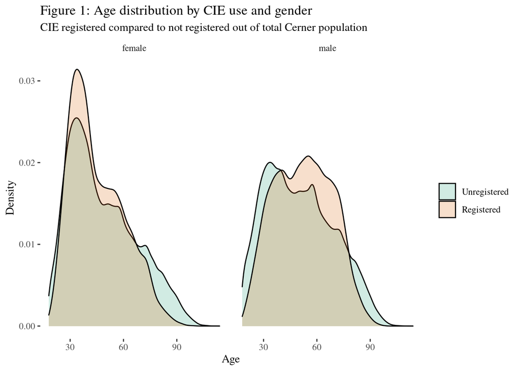

This is a Tukey style “box and whisker” plot showing median and IQR:

upper hinge, 75% quantile

lower hinge, 25% quantile

upper whisker = largest observation less than or equal to upper hinge + 1.5 * IQR

lower whisker = smallest observation greater than or equal to lower hinge - 1.5 * IQR

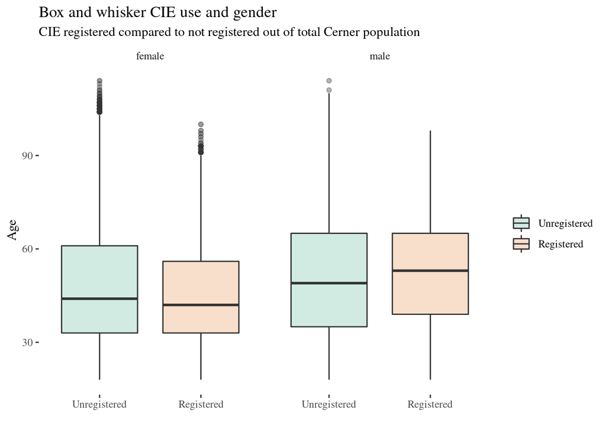

### Mean and SD

info: registration means, sd, by age and gender

NB data not normally distributed so mean and SD don't mean much

| mean | sd |
| --- | --- |
| female - Unregistered |  |
| 48.35974 | 18.72515 |
| female - Registered |  |
| 45.27419 | 15.16605 |
| male - Unregistered |  |
| 50.56062 | 18.89000 |
| male - Registered |  |
| 52.44109 | 16.03946 |

## Table 1

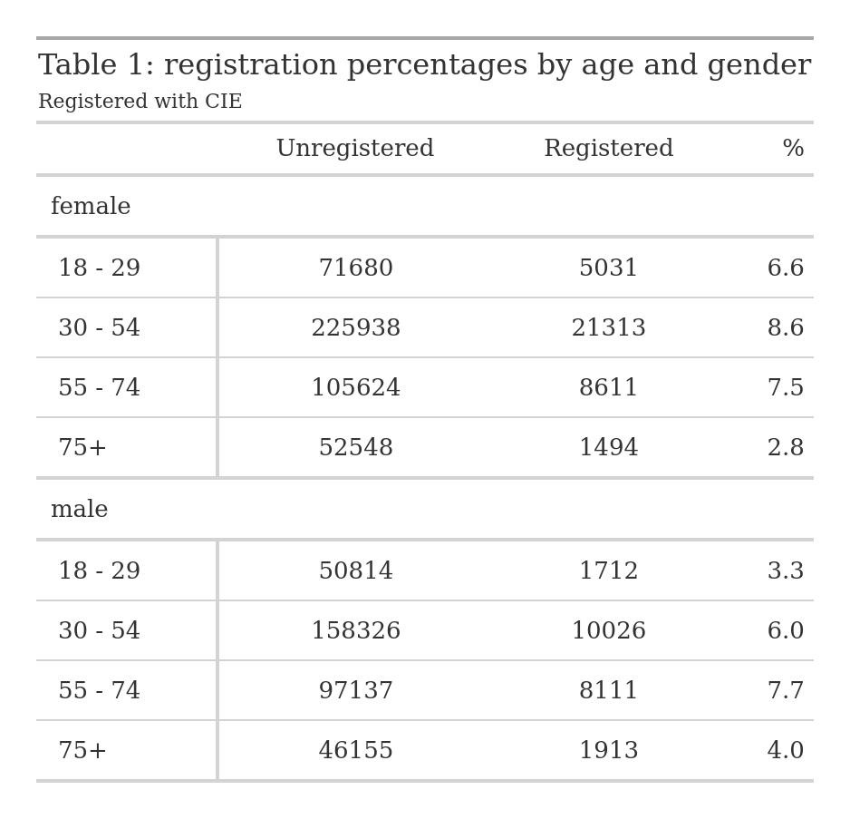

## Table 2

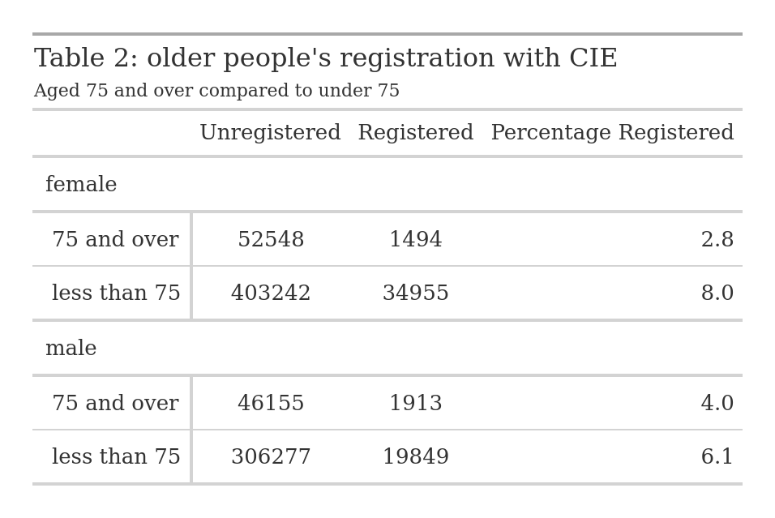

# Figure 2

## Figure 2: Registration compared to the entire Cerner population.

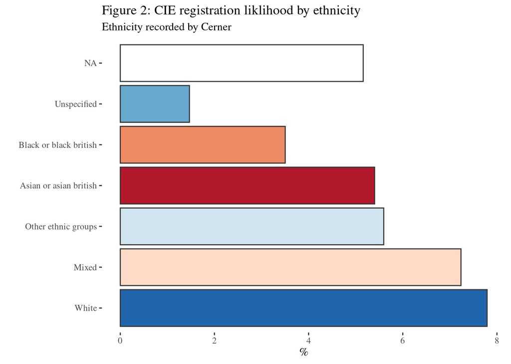

## info 1: proportions of ethnicities engaged from all Cerner, compared to White

Info 1: comparative proportions of ethnicities engaged from all Cerner

| Ethnicity | Percentage registered compared to white = 100 |
| --- | --- |
| Asian or asian british | 69.3 |
| Black or black british | 45.0 |
| Mixed | 92.9 |
| Other ethnic groups | 71.8 |
| Unspecified | 18.9 |
| NA | 66.2 |

# Figure 3

## Figure 3a

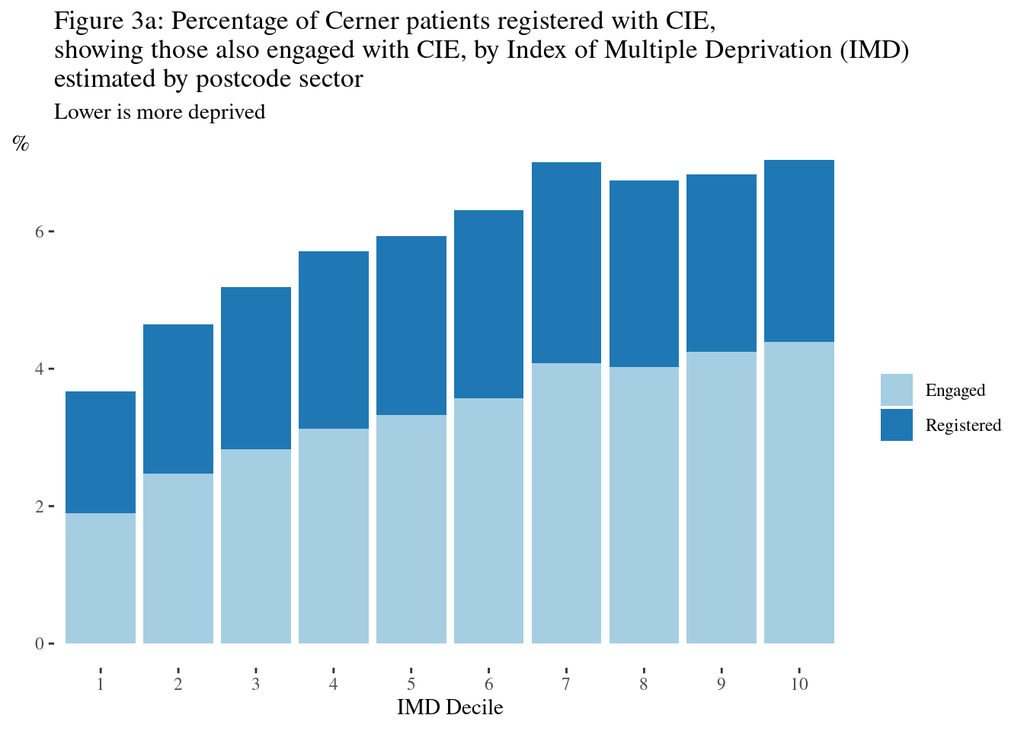

## info 3a: Index of Multiple Deprivation Decile Differences

Info 3a: the increase in liklihood of registration and engagement in the highest, compared to lowest, decile of the Index of Multiple Deprivation.

| Status | Lowest Decile | Highest Decile | Liklihood |
| --- | --- | --- | --- |
| Registered | 3.7 | 7.0 | 1.9 |
| Engaged | 1.9 | 4.4 | 2.3 |

## Figure 3b

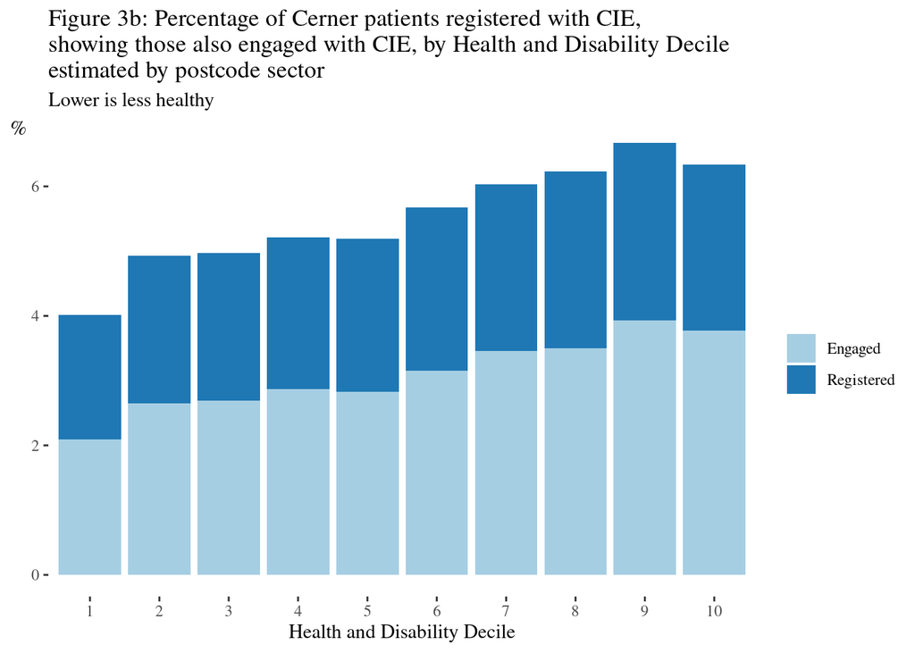

## info 3b: Health and Disability Decile Differences

Info 3b: the increase in liklihood of registration and engagement in the highest, compared to lowest, decile of the Health and Disability Index

| Status | Lowest Decile | Highest Decile | Liklihood |
| --- | --- | --- | --- |
| Registered | 4.0 | 6.3 | 1.6 |
| Engaged | 2.1 | 3.8 | 1.8 |

## Figure 3c

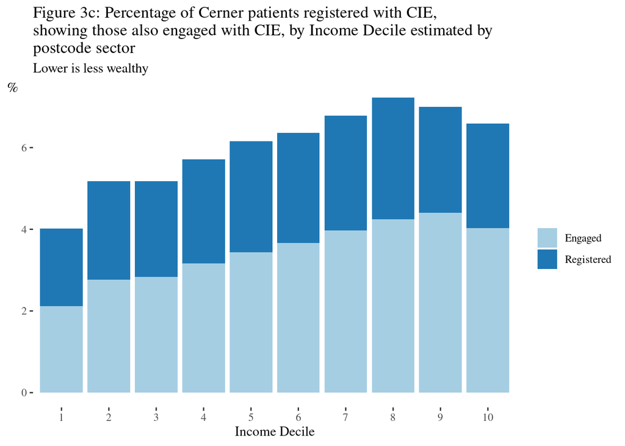

## info 3c: Income Decile Differences

Info 3c: the increase in liklihood of registration and engagement in the highest, compared to lowest, decile of Income

| Status | Lowest Decile | Highest Decile | Liklihood |
| --- | --- | --- | --- |
| Registered | 4.0 | 6.6 | 1.6 |
| Engaged | 2.1 | 4.0 | 1.9 |

# Figure 4

## Figure 4a

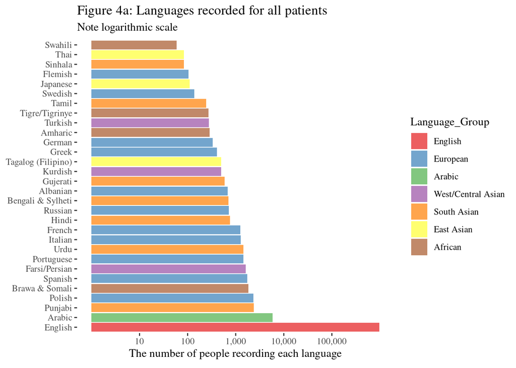

## info 4a: top 5 languages and percentages in Cerner group

Info 4a: top 5 languages and percentages in Cerner group

| Language | Count | % |
| --- | --- | --- |
| English | 966325 | 97.2 |
| Arabic | 5805 | 0.6 |
| Punjabi | 2360 | 0.2 |
| Polish | 2339 | 0.2 |
| Brawa & Somali | 1823 | 0.2 |

## Figure 4b

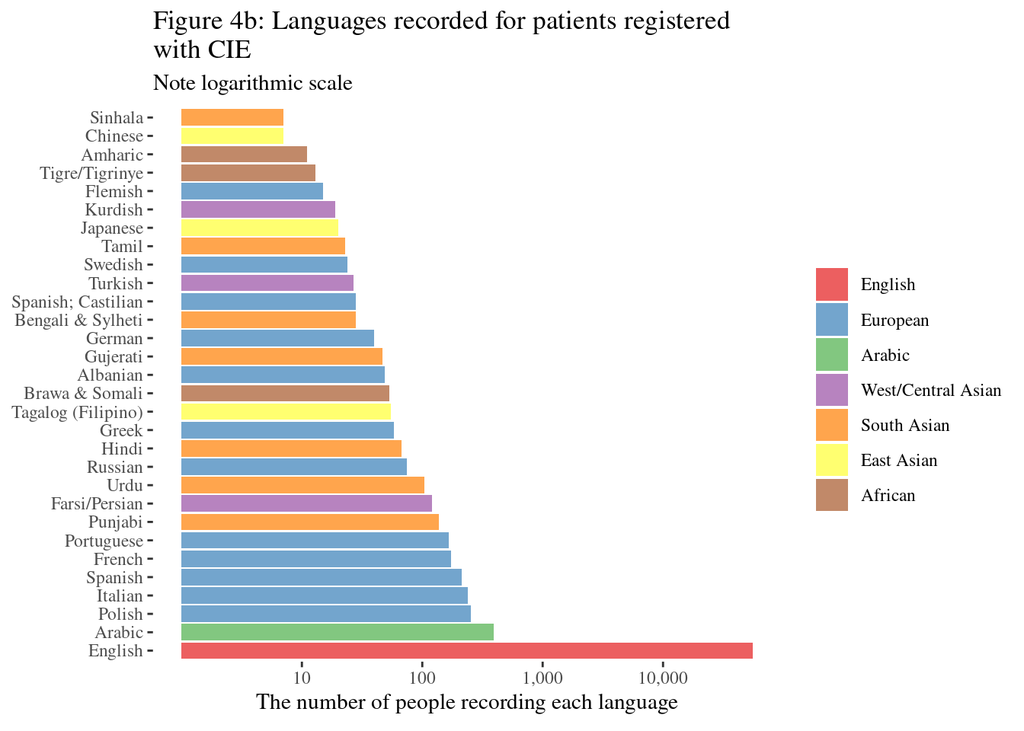

Info 4b: top 5 languages and percentages in CIE group

| Language | Count | % |
| --- | --- | --- |
| English | 55449 | 95.7 |
| Arabic | 390 | 0.7 |
| Polish | 253 | 0.4 |
| Italian | 240 | 0.4 |
| Spanish | 214 | 0.4 |

## Figure 4c

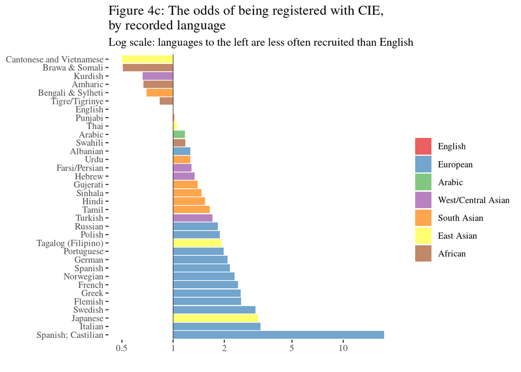

# Figure 5

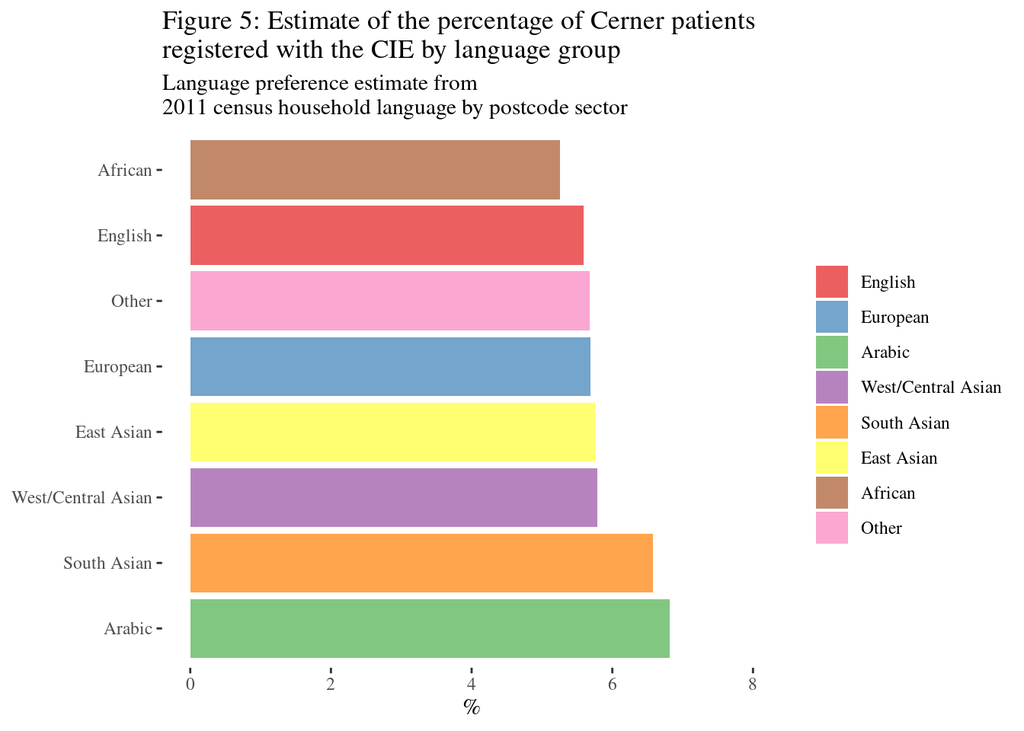

# Figure 6

## Figure 6a

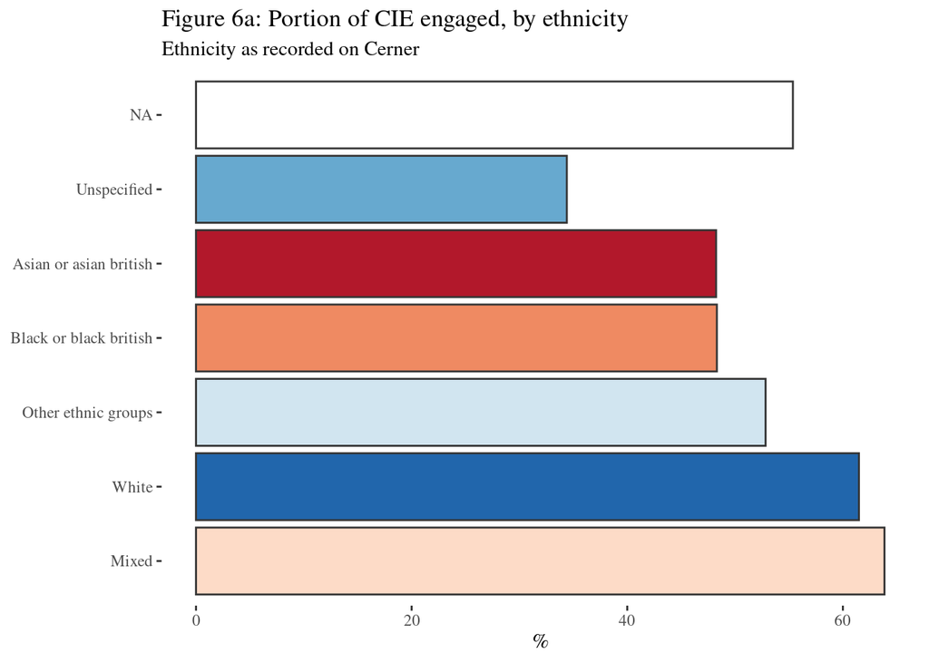

## Info 6a

Info 6a: additional data for Figure 6a in table form

| Ethnicity | Percentage engaged compared to white = 100 |
| --- | --- |
| Asian or asian british | 78.5 |
| Black or black british | 78.6 |
| Mixed | 103.9 |
| Other ethnic groups | 85.9 |
| Unspecified | 55.9 |
| NA | 90.0 |

## Figure 6b: Engagement compared to the the whole Cerner population.

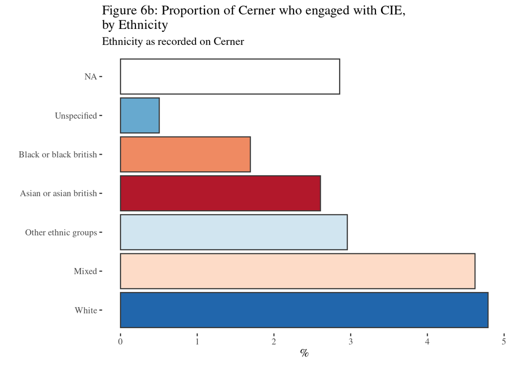

## Figure 6c

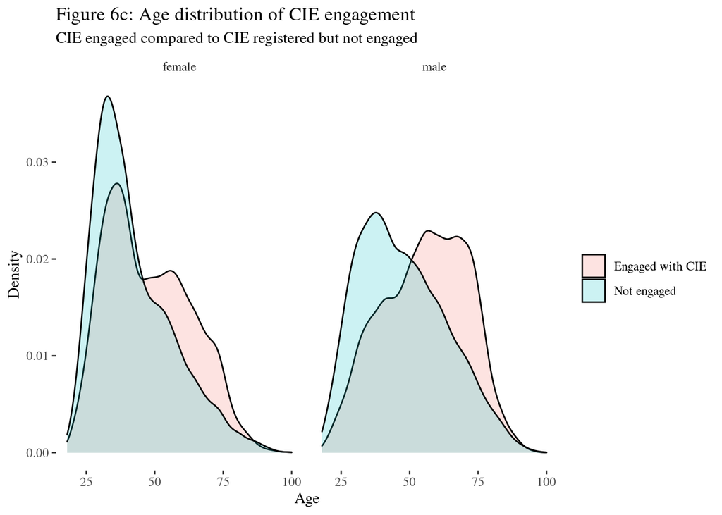

## info-6c - additional data for Figure 6c in table form

Info 6c: additional data for Figure 6c in table form

| gender | mean | median | mode | IQR | skewness | kurtosis |
| --- | --- | --- | --- | --- | --- | --- |
| Engaged_with_CIE |  |  |  |  |  |  |
| female | 47.9 | 46 | 37 | 25 | 0.37 | -0.76 |
| male | 55.7 | 57 | 56 | 24 | -0.17 | -0.76 |
| Not_engaged_with_CIE |  |  |  |  |  |  |
| female | 42.1 | 39 | 34 | 20 | 0.93 | 0.41 |
| male | 47.5 | 46 | 38 | 24 | 0.45 | -0.53 |

## Figure 6d

## Figure 6d: answering of questionnaires compared to the whole CIE group, by ethnicity.

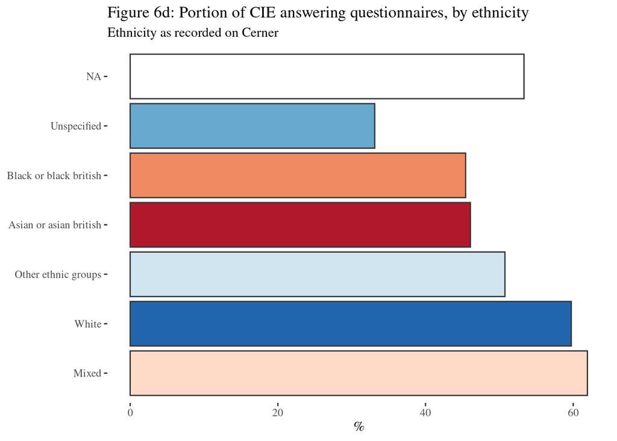

## info 6d - additional data for Figure 6d in table form

Info 6d: additional data for Figure 6d in table form

| Ethnicity | Percentage doing questionnaire compared to white = 100 |
| --- | --- |
| Asian or asian british | 77.1 |
| Black or black british | 76.1 |
| Mixed | 103.7 |
| Other ethnic groups | 85.0 |
| Unspecified | 55.4 |
| NA | 89.3 |

# Figure 7

## Figure 7a

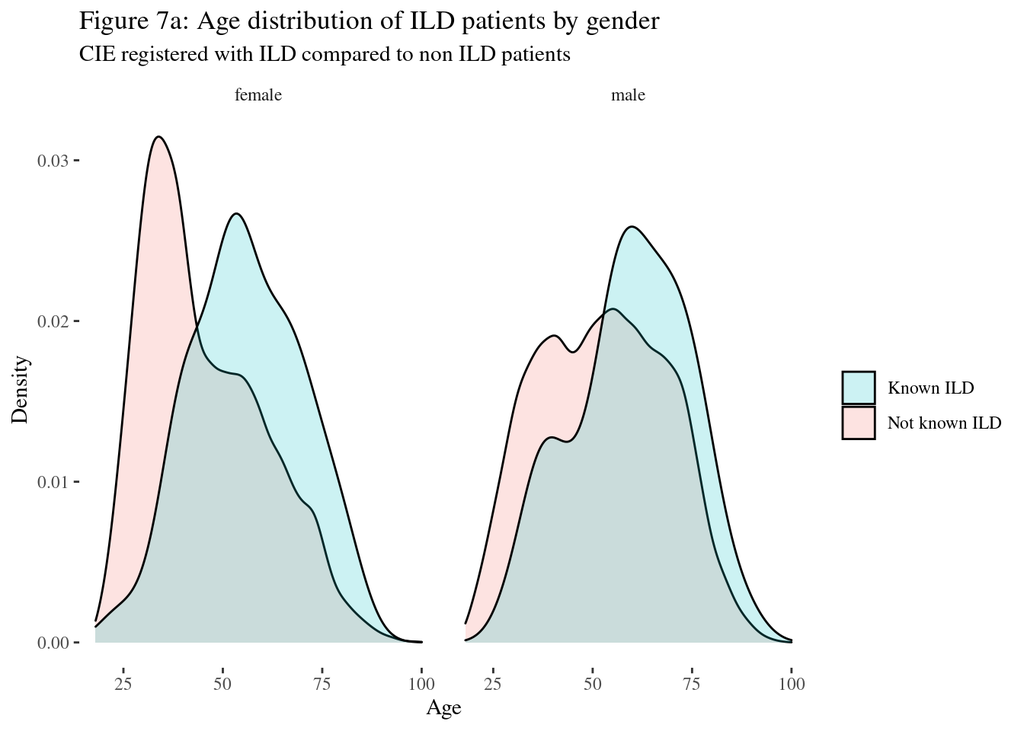

## info 7a - additional data for Figure 7a in table form

Info 7a: additional data for Figure 7a in table form

| Is ILD patient | Engaged | Not engaged | Percentage |
| --- | --- | --- | --- |
| Not_a_known_ILD_Patient | 32901 | 25128 | 56.7 |
| Known_ILD_Patient | 160 | 45 | 78.0 |

## info 7ai - 7aiii - additional data for Figure 7a in table form

Info 7ai: additional data for Figure 7a in table form

|  | mean | median | mode | IQR | skewness | kurtosis |
| --- | --- | --- | --- | --- | --- | --- |
| female |  |  |  |  |  |  |
| Not_a_known_ILD_Patient | 45.2 | 42 | 32 | 23 | 0.60 | -0.42 |
| Known_ILD_Patient | 56.1 | 55 | 52 | 20 | -0.02 | -0.62 |
| male |  |  |  |  |  |  |
| Not_a_known_ILD_Patient | 52.4 | 53 | 56 | 26 | 0.05 | -0.87 |
| Known_ILD_Patient | 59.6 | 60 | 56 | 19 | -0.22 | -0.73 |

info-7-a-ii,: ILD patient age details

|  | mean | median | mode | IQR | skewness | kurtosis |
| --- | --- | --- | --- | --- | --- | --- |
| Not_a_known_ILD_Patient | 47.9 | 46 | 32 | 25 | 0.39 | -0.74 |
| Known_ILD_Patient | 58.0 | 58 | 56 | 21 | -0.12 | -0.69 |

Table 7c: Liklihoods of answering COVID questionnaires, by ILD status

|  | Answered (%) |
| --- | --- |
| Not_a_known_ILD_Patient | 32 |
| Known_ILD_Patient | 46 |

## info 7a-iiii - additional data **NEW**

info 7aiiii: Liklihoods of answering any questionnaire, by ILD status

|  | Didn't answer questionnaire | Answered questionnaire | Answering_Portion |
| --- | --- | --- | --- |
| Not_a_known_ILD_Patient | 26274 | 31755 | 54.72264 |
| Known_ILD_Patient | 52 | 153 | 74.63415 |

## Figure 7b: ILD patients compared to the registered population.

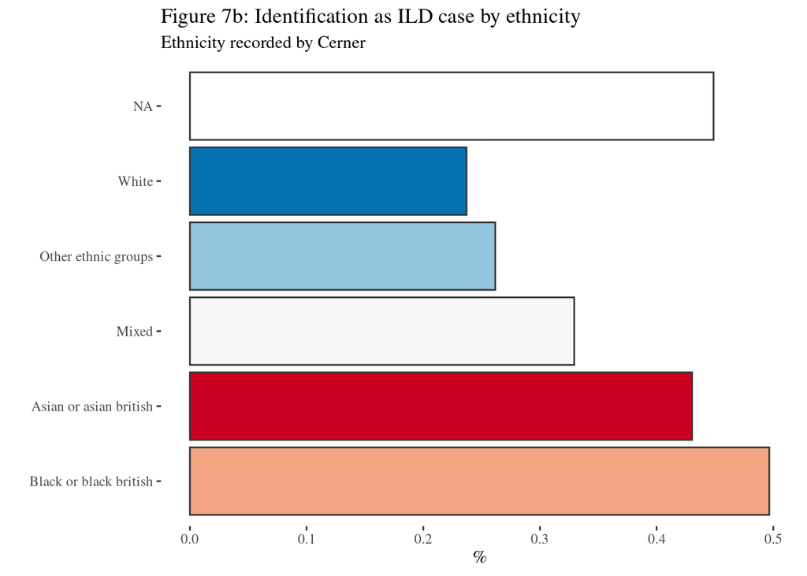

## Table 3: ILD registration numbers by ethnicity, compared to registered population

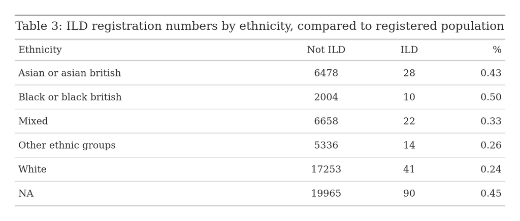

## Figure 7c: ILD registration compared to non-ILD registration.

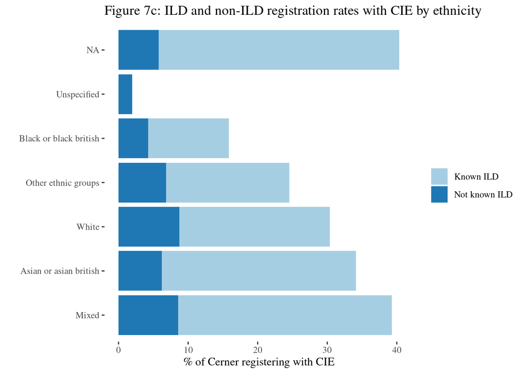

The total Cerner patients = 998249

The total CIE patients = 58234

The total ILD patients = 617

The total ILD registered CIE patients = 205